# Sweetgum Genetic Study

Andrea De Stefano

2023-12-01

# General info

I created this website to track the progress with the sweetgum genetic study.

There are 7 parts:

1. Libraries, dataset loading, and data wrangling.
2. SAS code.
3. Survival rate plots.
4. Groundline diameter (GLD) plots and stats.
5. Tree height plots and stats.
6. DBH plots and stats.
7. Live crown height plots and stats.

## Data Wrangling

```r
library(tidyverse)
library(ggpubr)

sweetgum_genetic1 <- read.csv("https://raw.githubusercontent.com/azd169/R-datasets/main/sweetgum_genetic.csv",
                              header = T)

sweetgum_genetic <- sweetgum_genetic1 %>%
  dplyr::mutate_if(is.integer, as.numeric) %>%
  dplyr::mutate_if(is.character, as.factor) %>%
  dplyr::mutate(Location = recode_factor(Location,
                                         "LA_Tech" = "LA Tech",
                                         "Hill_Farm" = "Hill Farm")) %>%
  dplyr::mutate(Year = recode_factor(Year,
                                     "Year_0" = "Initial",
                                     "Year_1" = "First",
                                     "Year_2" = "Second",
                                     "Year_3" = "Third",
                                     "Year_4" = "Fourth",
                                     "Year_5" = "Fifth",
                                     "Year_6" = "Sixth",
                                     "Year_7" = "Seventh"))

# Robert's dataset for his thesis

hane_gld <- sweetgum_genetic %>%
  subset(Year %in% c("Initial", "First", "Second")) %>%
  subset(Border %in% c("0")) %>% #
  dplyr::group_by(Year, Location, Family, Block) %>%
  dplyr::summarize(GLD = mean(GLD, na.rm = T)) %>%
  dplyr::mutate(GLB = paste(Family, Location, Block, sep = "_"))
hane_dbh <- sweetgum_genetic %>%
  subset(Year %in% c("Third", "Fourth", "Fifth", "Sixth", "Seventh")) %>%
  subset(Border %in% c("0")) %>% #
  dplyr::group_by(Year, Location, Family, Block) %>%
  dplyr::summarize(DBH = mean(DBH, na.rm = T)) %>%
  dplyr::mutate(GLB = paste(Family, Location, Block, sep = "_"))
hane_crown <- sweetgum_genetic %>%
  subset(Year %in% c("Fifth", "Sixth", "Seventh")) %>%
  subset(Border %in% c("0")) %>% #
  dplyr::group_by(Year, Location, Family, Block) %>%
  dplyr::summarize(Crown = mean(Crown_height, na.rm = T)) %>%
  dplyr::mutate(GLB = paste(Family, Location, Block, sep = "_"))
hane_ht <- sweetgum_genetic %>%
  dplyr::select(-c(GLD, DBH, Crown_height, Survival)) %>%
  subset(Border %in% c("0")) %>%
  group_by(Year, Location, Family, Block) %>%
  summarize(Height = mean(Height, na.rm = T)) %>%
  mutate(GLB = paste(Family, Location, Block, sep = "_")) %>%
  mutate(Year = as.factor(Year),
         Location = as.factor(Location),
         Family = as.factor(Family),
         GLB = as.factor(GLB))
hane_survival_year <- sweetgum_genetic %>%
  subset(Year %in% c("Initial", "First", "Second")) %>%
  subset(Border %in% c("0")) %>%
  group_by(Year, Survival) %>%
  summarise(n = n()) %>%
  mutate(Rate = (n / sum(n))*100)
hane_survival_year_location <- sweetgum_genetic %>%
  subset(Year %in% c("Initial", "First", "Second")) %>%
  subset(Border %in% c("0")) %>%
  group_by(Year, Location, Survival) %>%
  summarise(n = n()) %>%
  mutate(Rate = (n / sum(n))*100)
hane_survival_year_family <- sweetgum_genetic %>%
  subset(Year %in% c("Initial", "First", "Second")) %>%
  subset(Border %in% c("0")) %>%
  group_by(Year, Family, Survival) %>%
  summarise(n = n()) %>%
  mutate(Rate = (n / sum(n))*100)
hane_survival_year_location_family <- sweetgum_genetic %>%
  subset(Year %in% c("Initial", "First", "Second")) %>%
  subset(Border %in% c("0")) %>%
  group_by(Year, Location, Family, Survival) %>%
  summarise(n = n()) %>%
  mutate(Rate = (n / sum(n))*100)
```

## SAS Code

Procedure:

Datasets used:

1. WORK.DBH for DBH
2. WORK.GLD for GLD
3. WORK.HEIGHT for tree height
4. WORK.CROWN for crown height

Here are the SAS models:

1. GLD

PROC GLIMMIX DATA = GLD H PLOTS = ALL; CLASS Year Location Block Family GLB; MODEL GLD = Year|Location|Family / SOLUTION DDFM = KR; RANDOM intercept / SOLUTION SUBJECT = GLB TYPE = AR(1) CL; LSMEANS Location Family Year * Location Year * Family/ ADJUST = TUKEY LINES; ODS GRAPHICS OFF; RUN;

2. Height

PROC GLIMMIX DATA = HEIGHT H PLOTS = ALL; CLASS Year Location Block Family GLB; MODEL Height = Year|Location|Family / SOLUTION DDFM = KR; RANDOM intercept / SOLUTION SUBJECT = GLB TYPE = AR(1) CL; LSMEANS Family/ ADJUST = TUKEY LINES; SLICE Year * Location / SLICEBY = Year ADJUST = TUKEY LINES DIFF; SLICE Year * Family / SLICEBY = Year ADJUST = TUKEY LINES DIFF; ODS GRAPHICS OFF; RUN;

3. DBH

PROC GLIMMIX DATA = DBH H PLOTS = ALL; CLASS Year Location Block Family GLB; MODEL DBH = Year|Location|Family / SOLUTION DDFM = KR; RANDOM intercept / SOLUTION SUBJECT = GLB TYPE = AR(1) CL; LSMEANS Family/ ADJUST = TUKEY LINES; SLICE Year * Location / SLICEBY = Year ADJUST = TUKEY LINES DIFF; SLICE Year * Family / SLICEBY = Year ADJUST = TUKEY LINES DIFF; ODS GRAPHICS OFF; RUN;

4. Crown Height

PROC GLIMMIX DATA = CROWN H PLOTS = ALL; CLASS Year Location Block Family GLB; MODEL CROWN = Year|Location|Family / SOLUTION DDFM = KR; RANDOM intercept / SOLUTION SUBJECT = GLB TYPE = AR(1) CL; LSMEANS Family/ ADJUST = TUKEY LINES; SLICE Year * Location / SLICEBY = Year ADJUST = TUKEY LINES DIFF; SLICE Year * Family / SLICEBY = Year ADJUST = TUKEY LINES DIFF; ODS GRAPHICS OFF; RUN;

## Survival rates

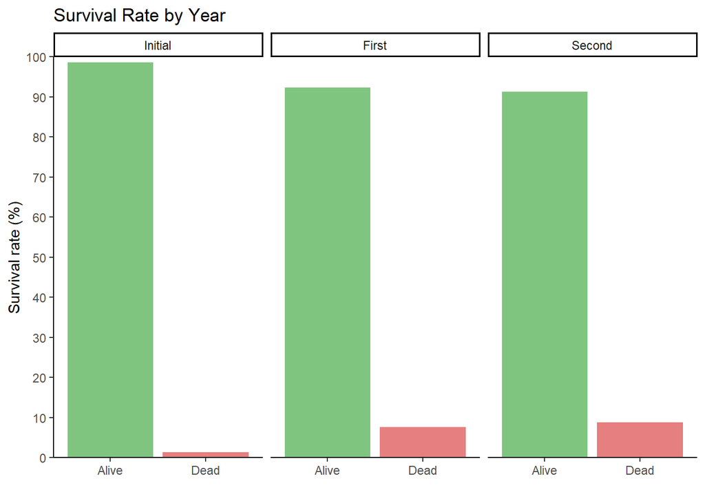

```r
Sur1 <- ggplot(hane_survival_year,
               aes(x = Survival, y = Rate, fill = Survival)) +
  stat_summary(fun = mean, geom = "bar", position = "dodge") +
  font("title", size = 22) +
  font("xlab", size = 18) +
  font("ylab", size = 18) +
  font("xy.text", size = 16) +
  scale_y_continuous(limits = c(0, 100), breaks = c(0, 10, 20, 30, 40, 50, 60, 70, 80, 90, 100), expand = c(0,0)) +
  scale_fill_manual(values = alpha(c("green4", "red3"), 0.5)) +
  labs(title = "Survival Rate by Year") +
  xlab("") +
  ylab("Survival rate (%)") +
  facet_wrap( ~ Year) +
  guides(fill = "none") +
  theme_classic()

Sur1
```

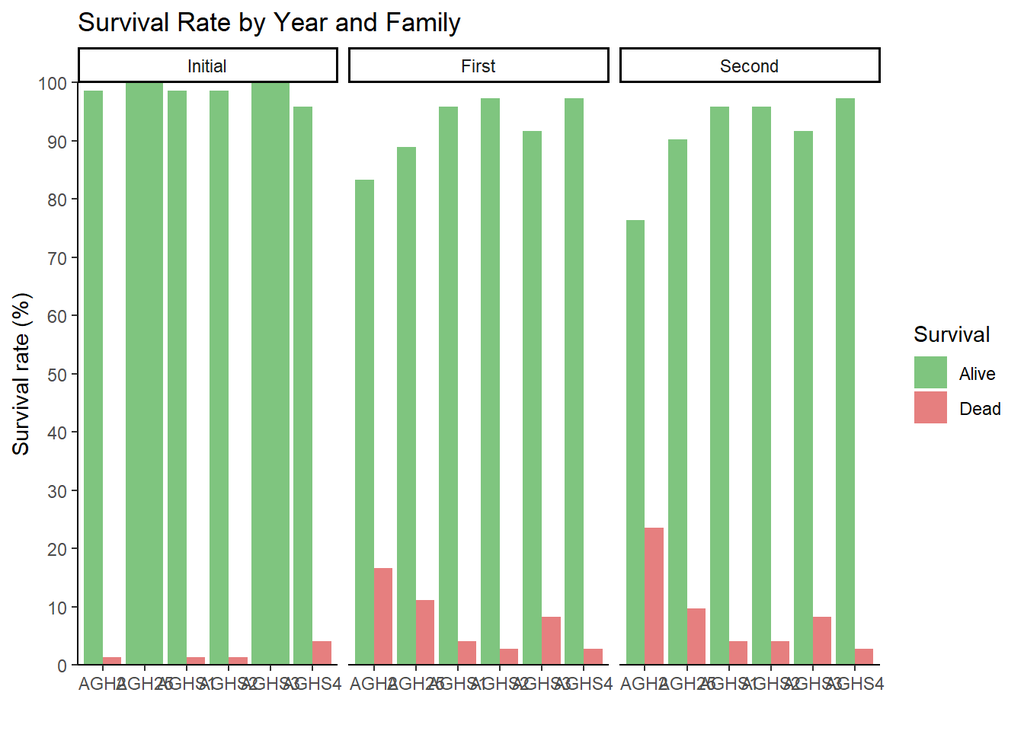

```r
Sur2 <- ggplot(hane_survival_year_family,
               aes(x = Family, y = Rate, fill = Survival)) +
  stat_summary(fun = mean, geom = "bar", position = "dodge") +
  font("title", size = 22) +
  font("xlab", size = 18) +
  font("ylab", size = 18) +
  font("xy.text", size = 16) +
  scale_y_continuous(limits = c(0, 100), breaks = c(0, 10, 20, 30, 40, 50, 60, 70, 80, 90, 100), expand = c(0,0)) +
  scale_fill_manual(values = alpha(c("green4", "red3"), 0.5)) +
  labs(title = "Survival Rate by Year and Family") +
  xlab("") +
  ylab("Survival rate (%)") +
  facet_wrap( ~ Year) +
  theme_classic()

Sur2
```

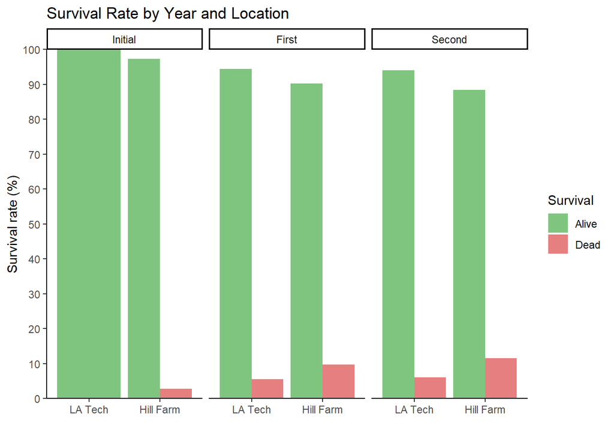

```r
Sur3 <- ggplot(hane_survival_year_location,
               aes(x = Location, y = Rate, fill = Survival)) +
  stat_summary(fun = mean, geom = "bar", position = "dodge") +
  font("title", size = 22) +
  font("xlab", size = 18) +
  font("ylab", size = 18) +
  font("xy.text", size = 16) +
  scale_y_continuous(limits = c(0, 100), breaks = c(0, 10, 20, 30, 40, 50, 60, 70, 80, 90, 100), expand = c(0,0)) +
  scale_fill_manual(values = alpha(c("green4", "red3"), 0.5)) +
  labs(title = "Survival Rate by Year and Location") +
  xlab("") +
  ylab("Survival rate (%)") +
  facet_wrap( ~ Year) +
  theme_classic()

Sur3
```

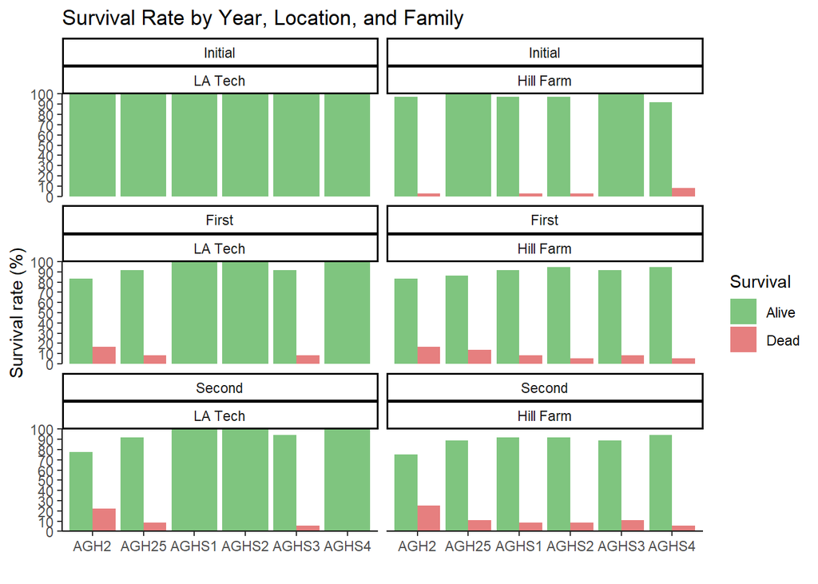

```r
Sur4 <- ggplot(hane_survival_year_location_family,
               aes(x = Family, y = Rate, fill = Survival)) +
  stat_summary(fun = mean, geom = "bar", position = "dodge") +
  font("title", size = 22) +
  font("xlab", size = 18) +
  font("ylab", size = 18) +
  font("xy.text", size = 16) +
  scale_y_continuous(limits = c(0, 100), breaks = c(0, 10, 20, 30, 40, 50, 60, 70, 80, 90, 100), expand = c(0,0)) +
  scale_fill_manual(values = alpha(c("green4", "red3"), 0.5)) +
  labs(title = "Survival Rate by Year, Location, and Family") +
  xlab("") +
  ylab("Survival rate (%)") +
  facet_wrap( ~ Year + Location, ncol = 2) +
  theme_classic()

Sur4
```

## GLD

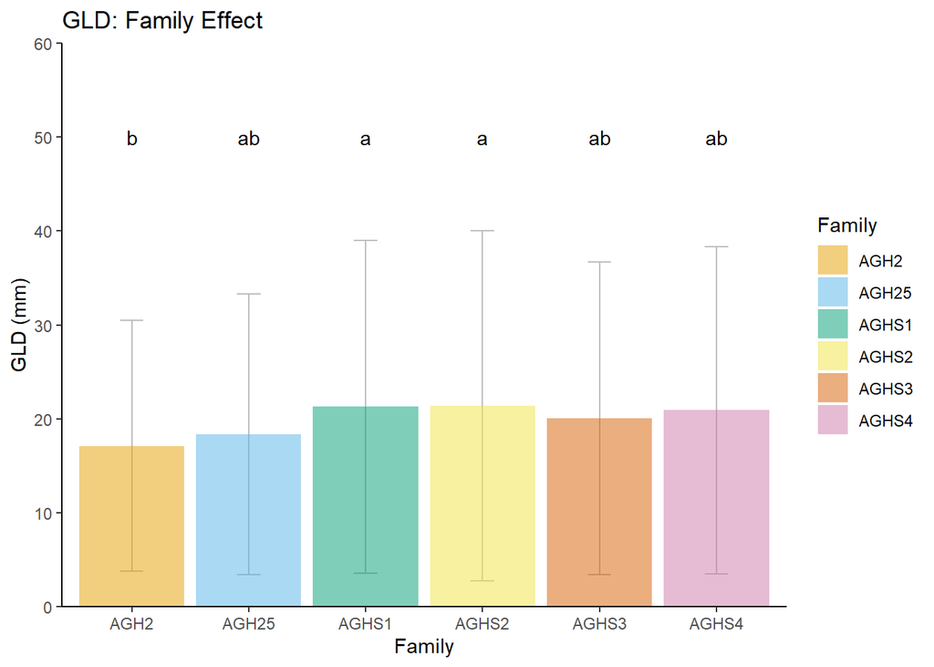

```r
Fig1 <- ggplot(hane_gld,
                 aes(x = Family, y = GLD, fill = Family)) +
  stat_summary(fun.data = mean_sd, geom = "errorbar", width = 0.2, color = "grey") +
  stat_summary(fun = mean, geom = "bar") +
  font("title", size = 22) +
  font("xlab", size = 18) +
  font("ylab", size = 18) +
  font("xy.text", size = 16) +
  scale_y_continuous(limits = c(0, 60), breaks = c(0, 10, 20, 30, 40, 50, 60), expand = c(0,0)) +
  scale_fill_manual(values = alpha(c("#E69F00", "#56B4E9", "#009E73",
                                     "#F0E442", "#D55E00", "#CC79A7"), 0.5)) +
  labs(title = "GLD: Family Effect") +
  xlab("Family") +
  ylab("GLD (mm)") +
  annotate("text",
           x = c(1, 2, 3, 4, 5, 6),
           y = c(50),
           label = c("b", "ab", "a", "a", "ab", "ab")) +
  theme_classic()

Fig1
```

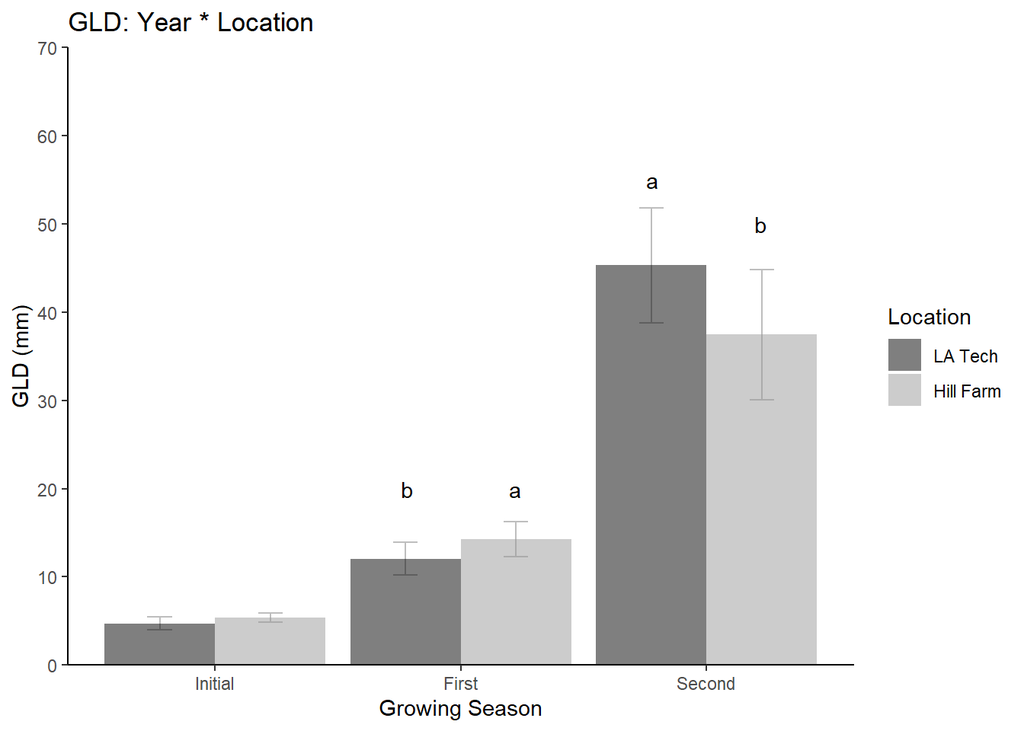

```r
Fig2 <- ggplot(hane_gld,
               aes(x = Year, y = GLD, fill = Location)) +
  stat_summary(fun.data = mean_sd, geom = "errorbar", position = position_dodge(0.9), width = 0.2, color = "grey") +
  stat_summary(fun = mean, geom = "bar", position = "dodge") +
  font("title", size = 22) +
  font("xlab", size = 18) +
  font("ylab", size = 18) +
  font("xy.text", size = 16) +
  scale_y_continuous(limits = c(0, 70), breaks = c(0, 10, 20, 30, 40, 50, 60, 70), expand = c(0,0)) +
  scale_fill_manual(values = alpha(c("#000000", "#999999"), 0.5)) +
  labs(title = "GLD: Year * Location") +
  xlab("Growing Season") +
  ylab("GLD (mm)") +
  annotate("text",
           x = c(1.78, 2.22, 2.78, 3.22),
           y = c(20, 20, 55, 50),
           label = c("b", "a", "a", "b")) +
  theme_classic()

Fig2
```

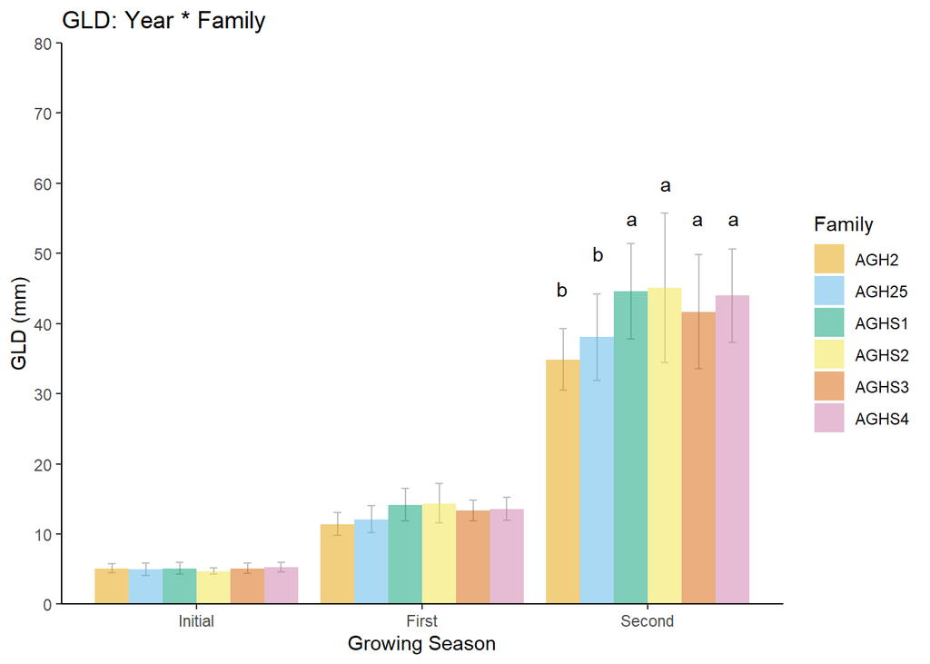

```r
Fig3 <- ggplot(hane_gld,
               aes(x = Year, y = GLD, fill = Family)) +
  stat_summary(fun.data = mean_sd, geom = "errorbar", position = position_dodge(0.9), width = 0.2, color = "grey") +
  stat_summary(fun = mean, geom = "bar", position = "dodge") +
  font("title", size = 22) +
  font("xlab", size = 18) +
  font("ylab", size = 18) +
  font("xy.text", size = 16) +
  scale_y_continuous(limits = c(0, 80), breaks = c(0, 10, 20, 30, 40, 50, 60, 70, 80), expand = c(0,0)) +
  scale_fill_manual(values = alpha(c("#E69F00", "#56B4E9", "#009E73",
                               "#F0E442", "#D55E00", "#CC79A7"), 0.5)) +
  labs(title = "GLD: Year * Family") +
  xlab("Growing Season") +
  ylab("GLD (mm)") +
  annotate("text",
           x = c(2.62, 2.78, 2.93, 3.08, 3.22, 3.38),
           y = c(45, 50, 55, 60, 55, 55),
           label = c("b", "b", "a", "a", "a", "a")) +
  theme_classic()

Fig3
```

## Height

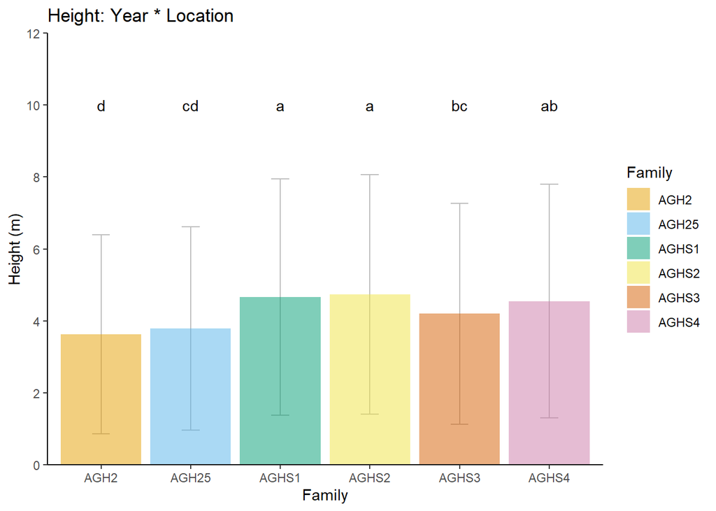

```r
Fig4 <- ggplot(hane_ht,
               aes(x = Family, y = Height, fill = Family)) +
  stat_summary(fun.data = mean_sd, geom = "errorbar", width = 0.2, color = "grey") +
  stat_summary(fun = mean, geom = "bar") +
  font("title", size = 22) +
  font("xlab", size = 18) +
  font("ylab", size = 18) +
  font("xy.text", size = 16) +
  scale_y_continuous(limits = c(0, 12), breaks = c(0, 2, 4, 6, 8, 10, 12), expand = c(0,0)) +
  scale_fill_manual(values = alpha(c("#E69F00", "#56B4E9", "#009E73",
                                     "#F0E442", "#D55E00", "#CC79A7"), 0.5)) +
  labs(title = "Height: Year * Location") +
  xlab("Family") +
  ylab("Height (m)") +
  annotate("text",
           x = c(1, 2, 3, 4, 5, 6),
           y = c(10),
           label = c("d", "cd", "a", "a", "bc", "ab")) +
  theme_classic()

Fig4
```

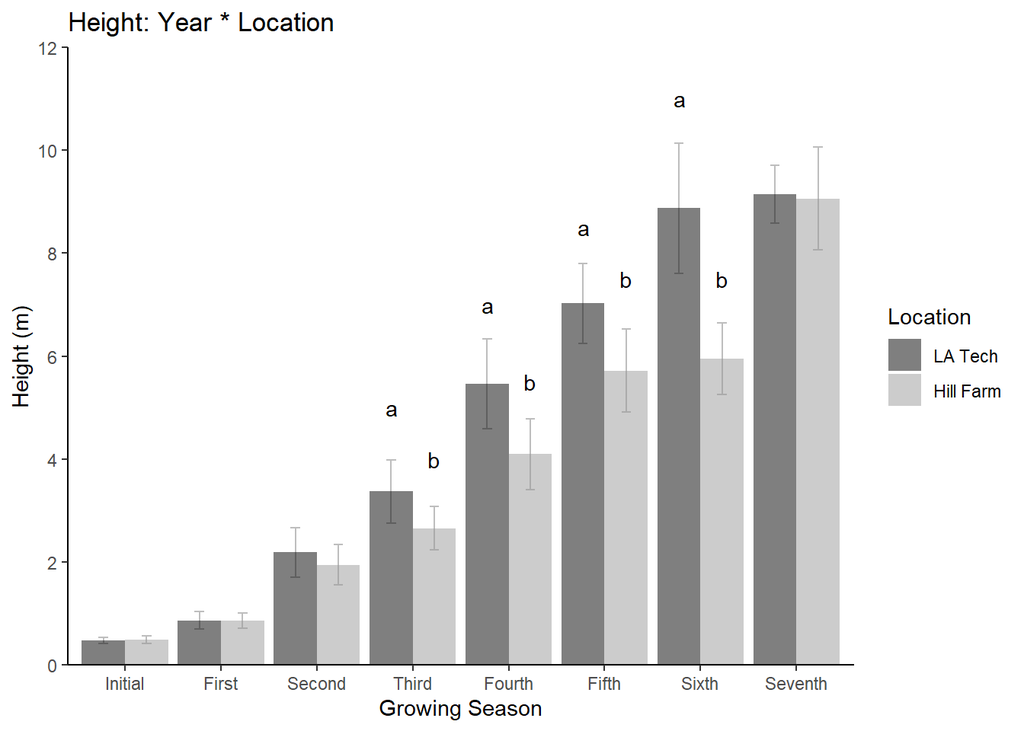

```r
Fig5 <- ggplot(hane_ht,
                  aes(x = Year, y = Height, fill = Location)) +
  stat_summary(fun.data = mean_sd, geom = "errorbar", position = position_dodge(0.9), width = 0.2, color = "grey") +
  stat_summary(fun = mean, geom = "bar", position = "dodge") +
  font("title", size = 22) +
  font("xlab", size = 18) +
  font("ylab", size = 18) +
  font("xy.text", size = 16) +
  scale_y_continuous(limits = c(0, 12), breaks = c(0, 2, 4, 6, 8, 10, 12), expand = c(0,0)) +
  scale_fill_manual(values = alpha(c("#000000", "#999999"), 0.5)) +
  labs(title = "Height: Year * Location" ) +
  xlab("Growing Season") +
  ylab("Height (m)") +
  annotate("text",
           x = c(3.78, 4.22, 4.78, 5.22, 5.78, 6.22, 6.78, 7.22),
           y = c(5, 4, 7, 5.5, 8.5, 7.5, 11, 7.5),
           label = c("a", "b", "a", "b", "a", "b", "a", "b")) +
  theme_classic()

Fig5
```

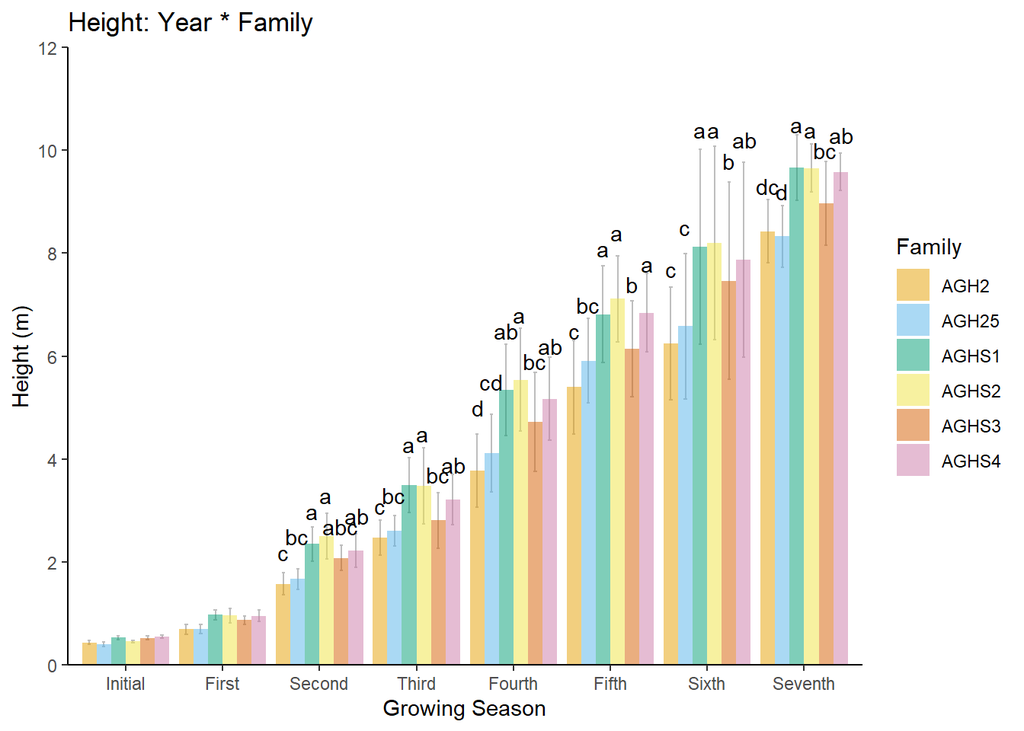

```r
Fig6 <- ggplot(hane_ht,
               aes(x = Year, y = Height, fill = Family)) +
  stat_summary(fun.data = mean_sd, geom = "errorbar", position = position_dodge(0.9), width = 0.2, color = "grey") +
  stat_summary(fun = mean, geom = "bar", position = "dodge") +
  font("title", size = 22) +
  font("xlab", size = 18) +
  font("ylab", size = 18) +
  font("xy.text", size = 16) +
  scale_y_continuous(limits = c(0, 12), breaks = c(0, 2, 4, 6, 8, 10, 12), expand = c(0,0)) +
  scale_fill_manual(values = alpha(c("#E69F00", "#56B4E9", "#009E73",
                                     "#F0E442", "#D55E00", "#CC79A7"), 0.5)) +
  labs(title = "Height: Year * Family") +
  xlab("Growing Season") +
  ylab("Height (m)") +
  annotate("text",
           x = c(2.63, 2.77, 2.92, 3.06, 3.22, 3.38,
                 3.63, 3.77, 3.92, 4.06, 4.22, 4.38,
                 4.63, 4.77, 4.92, 5.06, 5.22, 5.38,
                 5.63, 5.77, 5.92, 6.06, 6.22, 6.38,
                 6.63, 6.77, 6.92, 7.06, 7.22, 7.38,
                 7.63, 7.77, 7.92, 8.06, 8.22, 8.38
                 ),
           y = c(2.2, 2.5, 3, 3.3, 2.7, 2.9,
                 3.1, 3.3, 4.3, 4.5, 3.7, 3.9,
                 5, 5.5, 6.5, 6.8, 5.9, 6.2,
                 6.5, 7, 8.1, 8.4, 7.4, 7.8,
                 7.7, 8.5, 10.4, 10.4, 9.8, 10.2,
                 9.3, 9.2, 10.5, 10.4, 10, 10.3
                 ),
           label = c("c", "bc", "a", "a", "abc", "ab",
                     "c", "bc", "a", "a", "bc", "ab",
                     "d", "cd", "ab", "a", "bc", "ab",
                     "c", "bc", "a", "a", "b", "a",
                     "c", "c", "a", "a", "b", "ab",
                     "dc", "d", "a", "a", "bc", "ab"
                     )) +
  theme_classic()

Fig6
```

## DBH

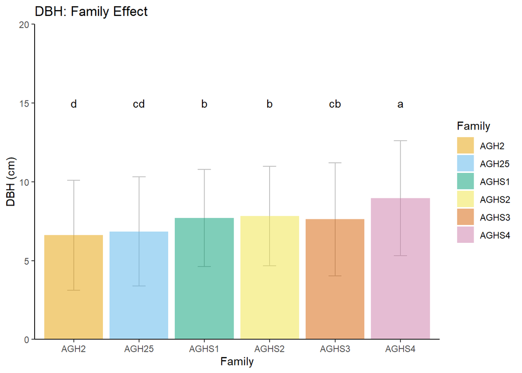

```r
Fig7 <- ggplot(hane_dbh,
               aes(x = Family, y = DBH, fill = Family)) +
  stat_summary(fun.data = mean_sd, geom = "errorbar", width = 0.2, color = "grey") +
  stat_summary(fun = mean, geom = "bar") +
  font("title", size = 22) +
  font("xlab", size = 18) +
  font("ylab", size = 18) +
  font("xy.text", size = 16) +
  scale_y_continuous(limits = c(0, 20), breaks = c(0, 5, 10, 15, 20), expand = c(0,0)) +
  scale_fill_manual(values = alpha(c("#E69F00", "#56B4E9", "#009E73",
                                     "#F0E442", "#D55E00", "#CC79A7"), 0.5)) +
  labs(title = "DBH: Family Effect") +
  xlab("Family") +
  ylab("DBH (cm)") +
  annotate("text",
           x = c(1, 2, 3, 4, 5, 6),
           y = c(15),
           label = c("d", "cd", "b", "b", "cb", "a")) +
  theme_classic()

Fig7
```

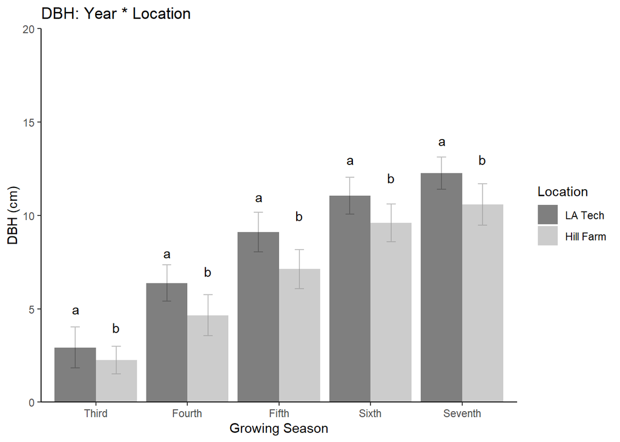

```r
Fig8 <- ggplot(hane_dbh,
               aes(x = Year, y = DBH, fill = Location)) +
  stat_summary(fun.data = mean_sd, geom = "errorbar", position = position_dodge(0.9), width = 0.2, color = "grey") +
  stat_summary(fun = mean, geom = "bar", position = "dodge") +
  font("title", size = 22) +
  font("xlab", size = 18) +
  font("ylab", size = 18) +
  font("xy.text", size = 16) +
  scale_y_continuous(limits = c(0, 20), breaks = c(0, 5, 10, 15, 20), expand = c(0,0)) +
  scale_fill_manual(values = alpha(c("#000000", "#999999"), 0.5)) +
  labs(title = "DBH: Year * Location" ) +
  xlab("Growing Season") +
  ylab("DBH (cm)") +
  annotate("text",
           x = c(0.78, 1.22, 1.78, 2.22, 2.78, 3.22, 3.78, 4.22, 4.78, 5.22),
           y = c(5, 4, 8, 7, 11, 10, 13, 12, 14, 13),
           label = c("a", "b", "a", "b", "a", "b", "a", "b", "a", "b")) +
  theme_classic()

Fig8
```

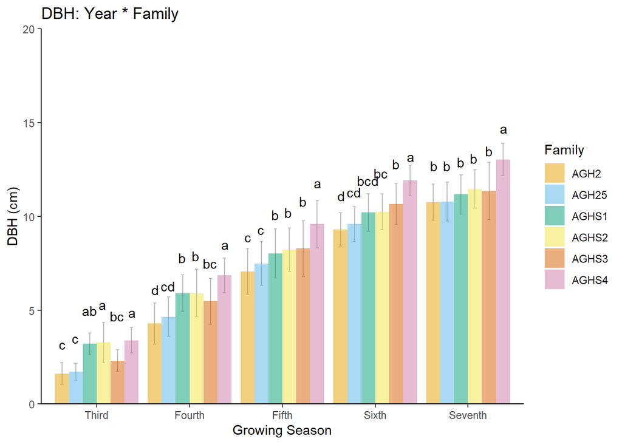

```r
Fig9 <- ggplot(hane_dbh,
               aes(x = Year, y = DBH, fill = Family)) +
  stat_summary(fun.data = mean_sd, geom = "errorbar", position = position_dodge(0.9), width = 0.2, color = "grey") +
  stat_summary(fun = mean, geom = "bar", position = "dodge") +
  font("title", size = 22) +
  font("xlab", size = 18) +
  font("ylab", size = 18) +
  font("xy.text", size = 16) +
  scale_y_continuous(limits = c(0, 20), breaks = c(0, 5, 10, 15, 20), expand = c(0,0)) +
  scale_fill_manual(values = alpha(c("#E69F00", "#56B4E9", "#009E73",
                                     "#F0E442", "#D55E00", "#CC79A7"), 0.5)) +
  labs(title = "DBH: Year * Family") +
  xlab("Growing Season") +
  ylab("DBH (cm)") +
  annotate("text",
           x = c(0.63, 0.77, 0.92, 1.06, 1.22, 1.38,
                 1.63, 1.77, 1.92, 2.06, 2.22, 2.38,
                 2.63, 2.77, 2.92, 3.06, 3.22, 3.38,
                 3.63, 3.77, 3.92, 4.06, 4.22, 4.38,
                 4.63, 4.77, 4.92, 5.06, 5.22, 5.38
           ),
           y = c(3.2, 3.5, 5, 5.3, 4.7, 4.9,
                 6.1, 6.3, 7.8, 7.9, 7.5, 8.5,
                 8.9, 9.3, 10.1, 10.2, 10.8, 11.8,
                 11.1, 11.3, 11.9, 12.3, 12.8, 13.2,
                 12.7, 12.7, 12.9, 13.1, 13.5, 14.7
           ),
           label = c("c", "c", "ab", "a", "bc", "a",
                     "d", "cd", "b", "b", "bc", "a",
                     "c", "c", "b", "b", "b", "a",
                     "d", "cd", "bcd", "bc", "b", "a",
                     "b", "b", "b", "b", "b", "a"
           )) +
  theme_classic()

Fig9
```

## Crown

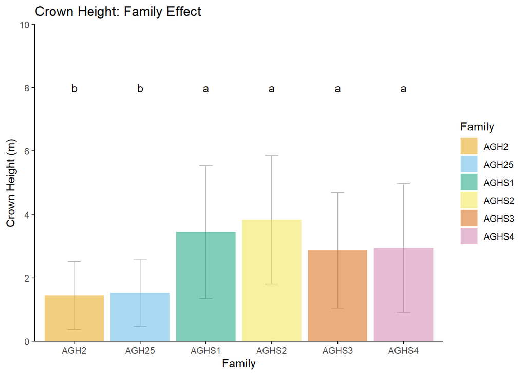

```r
Fig10 <- ggplot(hane_crown,
                aes(x = Family, y = Crown, fill = Family)) +
  stat_summary(fun.data = mean_sd, geom = "errorbar", width = 0.2, color = "grey") +
  stat_summary(fun = mean, geom = "bar") +
  font("title", size = 22) +
  font("xlab", size = 18) +
  font("ylab", size = 18) +
  font("xy.text", size = 16) +
  scale_y_continuous(limits = c(0, 10), breaks = c(0, 2, 4, 6, 8, 10), expand = c(0,0)) +
  scale_fill_manual(values = alpha(c("#E69F00", "#56B4E9", "#009E73",
                                     "#F0E442", "#D55E00", "#CC79A7"), 0.5)) +
  labs(title = "Crown Height: Family Effect") +
  xlab("Family") +
  ylab("Crown Height (m)") +
  annotate("text",
           x = c(1, 2, 3, 4, 5, 6),
           y = c(8),
           label = c("b", "b", "a", "a", "a", "a")) +
  theme_classic()

Fig10
```

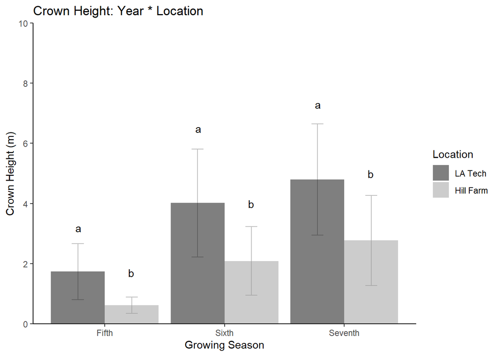

```r
Fig11 <- ggplot(hane_crown,
               aes(x = Year, y = Crown, fill = Location)) +
  stat_summary(fun.data = mean_sd, geom = "errorbar", position = position_dodge(0.9), width = 0.2, color = "grey") +
  stat_summary(fun = mean, geom = "bar", position = "dodge") +
  font("title", size = 22) +
  font("xlab", size = 18) +
  font("ylab", size = 18) +
  font("xy.text", size = 16) +
  scale_y_continuous(limits = c(0, 10), breaks = c(0, 2, 4, 6, 8, 10), expand = c(0,0)) +
  scale_fill_manual(values = alpha(c("#000000", "#999999"), 0.5)) +
  labs(title = "Crown Height: Year * Location" ) +
  xlab("Growing Season") +
  ylab("Crown Height (m)") +
  annotate("text",
           x = c(0.78, 1.22, 1.78, 2.22, 2.78, 3.22),
           y = c(3.2, 1.7, 6.5, 4, 7.3, 5),
           label = c("a", "b", "a", "b", "a", "b")) +
  theme_classic()

Fig11
```

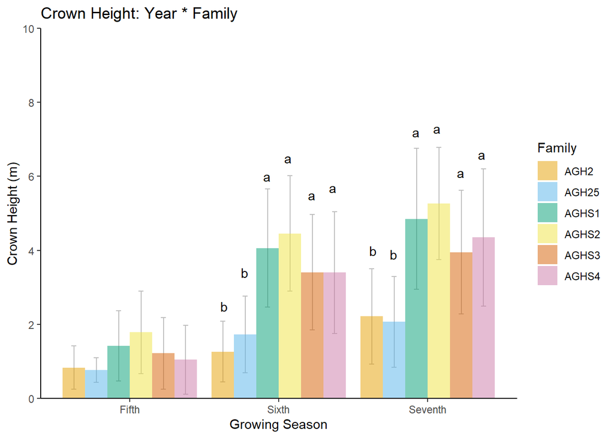

```r
Fig12 <- ggplot(hane_crown,
               aes(x = Year, y = Crown, fill = Family)) +
  stat_summary(fun.data = mean_sd, geom = "errorbar", position = position_dodge(0.9), width = 0.2, color = "grey") +
  stat_summary(fun = mean, geom = "bar", position = "dodge") +
  font("title", size = 22) +
  font("xlab", size = 18) +
  font("ylab", size = 18) +
  font("xy.text", size = 16) +
  scale_y_continuous(limits = c(0, 10), breaks = c(0, 2, 4, 6, 8, 10), expand = c(0,0)) +
  scale_fill_manual(values = alpha(c("#E69F00", "#56B4E9", "#009E73",
                                     "#F0E442", "#D55E00", "#CC79A7"), 0.5)) +
  labs(title = "Crown Height: Year * Family") +
  xlab("Growing Season") +
  ylab("Crown Height (m)") +
  annotate("text",
           x = c(1.63, 1.77, 1.92, 2.06, 2.22, 2.36,
                 2.63, 2.77, 2.92, 3.06, 3.22, 3.36
           ),
           y = c(2.5, 3.4, 6, 6.5, 5.5, 5.7,
                 4, 3.9, 7.2, 7.3, 6.1, 6.6
           ),
           label = c("b", "b", "a", "a", "a", "a",
                     "b", "b", "a", "a", "a", "a"
           )) +
  theme_classic()

Fig12
```